# Practical Machine Learning

Vishal Arora

December 22, 2015

```
                                            ***Executive Summary***
```

**Data loading and Cleaning**

Data is loaded from csv file provided at the Coursera. In this dataset, quite a few entries are either marked as missing or NA. I have checked for columns where more than 95% of data is either filled with NAs or empty strings. This check has given list of 100 columns. Since columns with such a huge number of NAs couldn’t be significant predictor, I have removed these columns from the dataset. After removing the NA cols, I have looked for columns where there is Zero and near zero variations, As columns with near zero/zero variations does not play significant role in predictions. Above check filtered out one more column. Following this, I decided to drop columns describing name of person, serial number of record. Since performance of activities are not time bound, I have dropped the time columns as well. Furthermore, output column’s data type has been changed to Factor from character, this will help to properly classify the predictions.

**Dividing data into Training and Test subsets**

Following some cleaning of data, I have divided data in to 2 subsets, where 80% of data has gone into Training and 20% in to test. We do not have any separate dataset for testing. Thus, testing subset will provide us good feedback about accuracy of our model derived from training subset.

**Data normalization and outlier extraction**

In this section, I have used BoxCox method to normalise the training data. More skewed data generates predictions with high error rate. After normalising the training data, using quantiles, I found a few outliers in 4 columns. I have filtered those records where I found outliers. Total 4 rows are deleted from the training subset.

Below is the plot featuring columns with outliers and output. *Outliers* are evident in the plots.

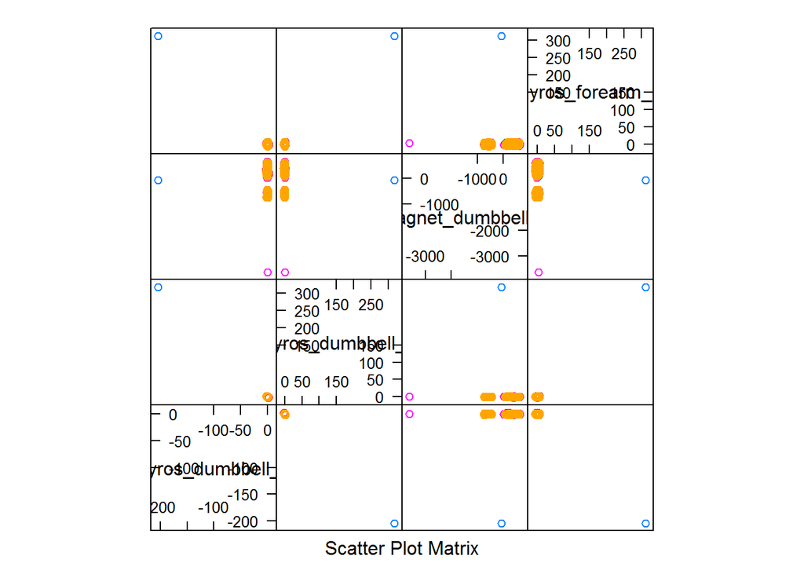

**Feature selection using PCA**

In this section, I have tried to find columns with high degree of correlation(more than 90%). Using all columns, which are highly correlated added insignificant accuracy to model on cost of a large computation code. This process has provided me 7 columns whose correlated columns are present in the dataset. Thus, I decided to drop these 7 columns as well.

Please Note we have to normalize the test data in the same way as we did the training.

**Below is the confusion matrix on Train Dataset, which is able to Identify all the records correctly**

```
## Confusion Matrix and Statistics
##
##           Reference
## Prediction    A    B    C    D    E
##          A 4460    0    0    0    0
##          B    0 3038    0    0    0
##          C    0    0 2738    0    0
##          D    0    0    0 2573    0
##          E    0    0    0    0 2886
##
## Overall Statistics
##
##                Accuracy : 1
##                  95% CI : (0.9998, 1)
##     No Information Rate : 0.2842
##     P-Value [Acc > NIR] : < 2.2e-16
##
##                   Kappa : 1
##  Mcnemar's Test P-Value : NA
##
## Statistics by Class:
##
##                      Class: A Class: B Class: C Class: D Class: E
## Sensitivity            1.0000   1.0000   1.0000   1.0000   1.0000
## Specificity            1.0000   1.0000   1.0000   1.0000   1.0000
## Pos Pred Value         1.0000   1.0000   1.0000   1.0000   1.0000
## Neg Pred Value         1.0000   1.0000   1.0000   1.0000   1.0000
## Prevalence             0.2842   0.1936   0.1745   0.1639   0.1839
## Detection Rate         0.2842   0.1936   0.1745   0.1639   0.1839
## Detection Prevalence   0.2842   0.1936   0.1745   0.1639   0.1839
## Balanced Accuracy      1.0000   1.0000   1.0000   1.0000   1.0000
```

**Below is the confusion matrix on Test Dataset, which clearly states the accuracy of model**

```
## Confusion Matrix and Statistics
##
##           Reference
## Prediction    A    B    C    D    E
##          A 1116    0    0    0    0
##          B    0  759    0    0    0
##          C    0    2  682    0    0
##          D    0    0    1  642    0
##          E    0    0    0    0  721
##
## Overall Statistics
##
##                Accuracy : 0.9992
##                  95% CI : (0.9978, 0.9998)
##     No Information Rate : 0.2845
##     P-Value [Acc > NIR] : < 2.2e-16
##
##                   Kappa : 0.999
##  Mcnemar's Test P-Value : NA
##
## Statistics by Class:
##
##                      Class: A Class: B Class: C Class: D Class: E
## Sensitivity            1.0000   0.9974   0.9985   1.0000   1.0000
## Specificity            1.0000   1.0000   0.9994   0.9997   1.0000
## Pos Pred Value         1.0000   1.0000   0.9971   0.9984   1.0000
## Neg Pred Value         1.0000   0.9994   0.9997   1.0000   1.0000
## Prevalence             0.2845   0.1940   0.1741   0.1637   0.1838
## Detection Rate         0.2845   0.1935   0.1738   0.1637   0.1838
## Detection Prevalence   0.2845   0.1935   0.1744   0.1639   0.1838
## Balanced Accuracy      1.0000   0.9987   0.9990   0.9998   1.0000
```

**Prediction of test dataset**

Following the Normalization of test dataset, prediction with trained model gives us below outcome.

```
##  [1] B A B A A E D B A A B C B A E E A B B B
## Levels: A B C D E
```